# Evolution of Sex-Specific Recombination Rate

April L. Peterson, Bret Payseur

2020-05-14

#Intro

#Material Methods Draft v1

### Mouse Husbandry

To access natural genetic variation for *Mus musculus*, wild derived inbred strains were used. The *Mus musculus* strains PWD/PhJ, PERC/Eij, WSB/EiJ, LEWE/EiJ, MSM/MsJ, MOLF/EiJ, CAST/EiJ, CZECHII/EiJ were purchased from Jackson labs (Maine, USA). The strains of KAZ/TUA, TOM/TUA, AST/TUA, and HMI/TUA were generated from frozen embryos purchased from Biological Resource Center (BRC) at Riken (Ibaraki, Japan). (https://en.brc.riken.jp) and rederived by the UW-Biotech center (Madison UW). The related murid species *Mus caroli* CAROLI/EiJ and *Mus spretus* SPRET/EiJ were purchased from Jackson labs (https://www.jax.org) and *Mus spicilegus* SPIC/Eij from Riken. We use abbreviated superscript notation for the remainder of the paper (e.g. *musculus<sup>WSB</sup>*). All mice were housed UW-Madison Biotech and MSC facilities following RARC approved protocols. A breeding colony of wild derived *Mus musculus* mice sampled from Gough Island (G) is maintained at UW Veterinary school facilities.

### Tissue Collection and Immunohistochemistry

The same dry-down spread technique was applied to both spermatocytes and oocytes based on (Peters et al. 1997), with adjustment for volumes. Spermatocyte spreads were collected and prepared as described in (Peterson, Miller, and Payseur 2019). The majority of mice used MLH1 quantification were from mice between 5 and 12 weeks, while juvenile mice aged between 12 to 15 days were used for DMC1 quantification. Both pairs of ovaries were collected from embryo or neonate mice between 16 to 21 embryonic days and 0 to 48 hours old respectively. Whole testes and decapsulated ovaries were incubated in 3ml or 300ul of hypotonic solution for 45min respectively. Fifteen microliters of cell slurry (masticated gonads) were transferred to 80ul of 2% PFA solution. Cells were fixed in this solution and dried in a humid chamber at room temperature overnight. The following morning, slides were treated with a Photoflow wash (Kodak, cite). Slides were stored at -20*C if not stained immediately.

To visualize the structure of meiotic chromosomes we used antibody markers for the centromere (CREST) and lateral element of the synaptonemal complex (SC) (SYCP3). Double strand breaks (DSB) and COs were visualized with DMC1 and MLH1 respectively. The staining protocol was based on that in (Anderson et al. 1999) and (Koehler et al. 2002). Antibodies and slide blocking was performed in 1X antibody dilution buffer (ADB) (normal donkey serum (Jackson ImmnuoResearch), 1X PBS, bovine serum albumin (Sigma), Triton X-100 (Sigma) ).

Following a 30 minute blocking wash in ABD, each slide was incubated with 60ul of a primary antibody master mix for 48 hours at 37* C. The master mix recipe contained polyclonal anti rabbit anti-MLH1 (Calbiochem; diluted 1:50) or anti rabbit anti-DMC1) (mix of DMC1), anti goat polyclonal anti-SYCP3, (Abcam; diluted 1:50), and anti-human polyclonal antibody to CREST (Antibodies, Inc; diluted 1:200) suspended in ADB. Slides were washed twice in 50ml ADB before the first round of secondary antibody incubation for 12 hours at 37 degrees. Alexa Fluor 488 donkey anti-rabbit IgG (Invitrgoen, location; diluted to 1:100) and Coumarin AMCA donkey anti-human IgG (Jackson ImmunoResearch; diluted to 1:200) were suspended in ADB. The last incubation of Alexa Fluor 568 donkey anti-goat (Invitrogen; diluted 1:100) was incubated at 1:100 for 2 hours at 37 degrees. Slides were fixed with Prolong Gold Antifade (Invitrogen) for 24 hours after a final wash in 1x PBS.

### Image Processing

Images were capture using a Zeiss Axioplan 2 microscope with AxioLab camera and Axio Vision software (Zeiss, Cambridge, UK). Preprocessing, including cropping, noise reduction, and histogram adjustments, was performed using Photoshop (v13.0). Image file names were anonymized before manual scoring of MLH1 or DMC1 foci using photoshop.

### Analysis

To estimate the numbers of percursor sites which may lead to crossovers, the mean **DMC1** foci per cell for a single mouse from a subset of srains *musculus<sup>PWD</sup>*, *musculus<sup>MSM</sup>*, *domesticus<sup>WSB</sup>*, and *domesticus<sup>G</sup>* was quantified. SC morphology and CREST/centromere foci number was used to stage spermatocytes, in early and late zygotema stages.

**MLH1** foci were quantified from cells with intact and complete karyotypes (19 acrocentric bivalents and XY for spermatocytes or 20 acrocentric bivalents for oocytes) and distinct MLH1 foci. A quality score, between 1 to 5, was assigned to each cell based on staining quality and general spread of bivalents. With scores of 1 and 2 having the highest quality. Cells and coded as a score of 5 were excluded from the final analysis. The distributions of MLH1 counts per cell was assessed for normality (supplemental figure). MLH1 foci located on the XY in spermatocytes were excluded from this study.

**M1 Mixed Model**
$$mouse \ av.\ dependant\ variable\ ~=~ subsp * sex + rand(strain) + \varepsilon$$

**M2 Linear Model**
$$mouse \ av.\ dependant\ variable\ ~=~ subsp * sex * strain + \varepsilon$$

**M3 Linear Model**
$$mouse \ av.\ dependant\ variable\ ~=~ sex * strain + \varepsilon$$

**M4 Linear Model**
$$sex\ specific\ mouse \ av.\ dependant\ variable\ ~=~ subsp * strain + \varepsilon$$

**M5 Linear Model**
$$sex\ specific\ mouse \ av.\ dependant\ variable\ ~=~ strain + \varepsilon$$

A series of mixed models and general linear models were used as an analetical framework. We built the full mixed model (**M1**) to interpret the patterns of variation using the lmer() from the lmer4 package (cite) in R (v3.5.2)(Team 2015). Strain was coded as a random effect and tested using exactRLRT() to reflect a random sample of natural genetic variation from each subspecies. The main effects, subspecies, strain, and interaction were coded as fixed and tested by a chi-square test comparing the full and reduced models using drop1() and anova().

This model allows us to estimate and test the fixed effects (sex and subsp), and variation in mean MLH1 counts due to strain effect. We use the subspecies term as a way to quantify between group variation (or divergence) and the random strain effect to quantify within group variation (or polymorphism) in a sex specific manner. The remaining general linear models, (**M2-M3**), were used to follow up on results from the full mixed model. The general linear models, **M4** were used to analyze sex specific data sets.

Our goal was to design an analytical framework which accounts for the nested nature across categories across all the individual mice (e.g. sex, strain subspecies) and can be applied to multiple (meiotic traits) dependent variables. In addition to the MLH1 count variables for individual mice, mean MLH1 count per cell, variance and coefficient of variance for MLH1 count per cell, we analyzed SC based features: mouse average of total SC per cell, mouse average of single SC length, mouse mean IFD<sup>norm</sup> and IFD<sup>raw</sup> for double crossover chromosomes, and the average position of crossover for single crossover bivalents.

These traits were choosen because they are markers of phenomena in the recombinaiton pathway and provide more detailed information about the recombination landscape. In order to examine crossover interference, inter-focal distance (IFD) was measured from the single bivalents containing two crossovers. Normalized measures were calculated by the position divided by the length of the SC for that single bivalent.

### Single bivalent characterization

To characterize the SC length of individual chromosomes, two image analysis algorithms were used to quantify SC area for individual cells (Wang et al. 2019) and for individual bivalents (Peterson, Miller, and Payseur 2019). Both apply a ‘skeletonizing’ transformation to the synapsed chromosomes which produces a single pixel wide ‘trace’ of the original chromosome shape. Hand measures of pactyene chromosomes were performed by using ImageJ/Fiji (v1.52) (Schindelin et al. 2012).

The **DNA CrossOver** algorithm isolates single straightened bivalents shapes from an image, and returns SC length, and location of green and blue signal, reflecting MLH1 foci and cetromere signal respectively. This algorithm substantially speeds the accurate measurement of bivalents, but has the limitation that not all bivalents per cell can be isolated due to overlapping bivalents. In this data set, isolation rates per cell (the number of all bivalents per cell) range from 0.48 ( *molossinus<sup>MSM</sup>* male) to 0.72 ( *musculus<sup>KAZ</sup>* female).

A curation step was applied to the total single bivalent data set to remove poor measures from the algorithm. From the total set of cell images, 10,458 bivalent objects were isolated by the image analysis software. After a human curation step , 9,829 single-bivalent observations remained. The accuracy of the algorithm is high compared to hand measures after this curation step (Peterson, Miller, and Payseur 2019). From the curated single bivalent data set the **proportions** of bivalents by crossover number were quantified and tested by chi-square tests with the prop.test().

# Results

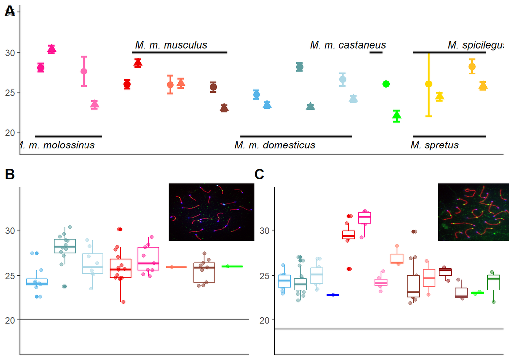

*Figure 1 Mean MLH1 count distributions by strain.* A) Strain averages of MLH1 counts per cell. B) Female specific MLH1 count distributions. C) Male specific MLH1 counts per cell.

## Genome-wide recombination rate estimates for both sexes

We used counts of MLH1 foci per cell to estimate genome-wide recombination rates in 14 wild-derived inbred strains sampled from three subspecies of house mice: *M. m. domesticus*, *M. m. musculus* and *M. m. molossinus*. Mean MLH1 foci counts for 159 mice were quantified from an average of 22.14 spermatocytes per male (for a total of 1,867 spermatocytes) and 18.76 oocytes per female (for a total of 1,409 oocytes).

Graphical comparisons between the two sexes reveal several patterns (Figure 1A). First, recombination rate differs between females and males in most strains. Second, the direction and magnitude of heterochiasmy varies among strains. Although the majority of strains show higher recombination rates in females (following the pattern in laboratory mice), two musculus strains and one molossinus strain exhibit male-biased heterochiasmy. Hence, relative recombination rates in the two sexes are evolutionarily labile.

The general patterns of heterochiasmy in house mouse are displayed in Figure 1A. Taking note of the direction and the magnitude of the sex differences, our results confirm two general patterns: i) genome-wide recombination rates averages are greater in females compared to males (female biased heterochiasmy) and ii) the degree of heterochiasmy (Female:Male ratio) is generally low, ranging from 1.22 in *domesticus<sup>G</sup>* to 1.06 in *domesticus<sup>LEW</sup>*. Three notable exceptions of male biased heterochiasmy are the strains *musculus<sup>PWD</sup>*, *molossinus<sup>MSM</sup>* and *musculus<sup>SKIVE</sup>*, with heterochiasmy values of 0.91, 0.93 and 0.99 respectively.

Separately examining the mouse means of MLH1 foci per cell for each sex points to distinct patterns of variation (Figure 1B-C). Female recombination rates are evenly distributed around the sex-wide mean of approximately 25 MLH1 foci per cell (Figure 1B). In stark contrast, males separate more clearly into two groups of strains with high rates (near 30 MLH1 foci per cell) and low rates (near 23 MLH1 foci per cell) (Figure 1C).

## Partitioning variation in recombination rate

To situate variation in recombination rate within an evolutionary framework, we fit a series of models including subspecies, strain, and sex, to mean MLH1 foci counts from 159 mice. We began with a full mixed model (M1, see Methods), which showed that strain (random effect p < 10^{-6}), sex (p = 5.5310^{-5}), subspecies (p=1.1210^{-4}), and subspecies sex (p = 3.1810^{-5}) each significantly affect recombination rate.

After a general linear model including all factors as fixed effects (M2) revealed only weak contributions of subspecies, we focused on additional models designed to illuminate the role of strain and sex. A general linear model with these two variables (M3) identified two strains with particularly strong effects on recombination rate: *musculus<sup>MSM</sup>* (p = 2.810^{-7}) and *domesticus<sup>G</sup>* (p = 8.110^{-8}). In addition, two strains exhibit strain-by-sex interactions: *molossinus<sup>MSM</sup>* (p = 0) and *musculus<sup>PWD</sup>* (p = 0).

These three strains point to rapid evolution in recombination rate in spermatocytes; we subsequently refer to them collectively as “high-recombination” strains. Analysis of the female dataset points to four strains with significant effects on recombination rate: *domesticus<sup>G</sup>* (p = 2.510^{-6}), *molossinus<sup>MSM</sup>* (p = 6.2410^{-6}), *domesticus<sup>LEW</sup>* (p = 0.01), and *musculus<sup>PWD</sup>* (p= 0.02). Strain effect sizes in females are modest in magnitude (ranging from 1 to 4 foci) compared to those in males. Together, these results demonstrate heritable differences in the genome-wide recombination rate evolving in a highly sex-specific manner over short evolutionary timescales.

## Sex Differences in Meiotic Traits

In many mammalian species, the synaptonemal complex (SC) is longer in females (Cahoon and Libuda 2019, @sardell_sex_2020). Yet, the majority of these observations come from species with female-biased heterochiasmy. Our wider survey of recombination in house mice provides an opportunity to determine whether sex differences in chromatin compaction (SC length) are reversed when heterochiasmy is male-biased. In addition, if SC length is a strong determinant of the genome-wide recombination rate, male *musculus<sup>PWD</sup>* and male *molossinus<sup>MSM</sup>* should have longer SC lengths than the other strains.

Females have significantly longer total SC than males in each strain tested separately (t-test; p < 0.05). That females have longer SCs is also supported by mixed models and general linear models with covariates, which identify sex as the most consistently significant effect (p < 0.05). Additionally, there are some significant subspecies and strain effects (p < 0.05), indicating that SC length has evolved among strains and subspecies, however further investigation is beyond the scope of this paper.

In summary, two approaches for measuring and analyzing SC length indicate that females have longer SCs (chromosome axes), even in strains where males have more MLH1 foci per cell. Furthermore, joint consideration of MLH1 foci and total SC length suggests that males from high-recombination strains have less “space” in which to place their additional crossovers compared to females.

### Positions of Single Crossovers

We used the single crossover bivalent (1CO) position to compared general location of crossovers while controlling for differences in total SC length. Given that, in most of the strains we surveyed, the majority of bivalents are observed to contain one crossover (focus), thus justifying the focus of single crossover bivalents for analyzing crossover positions.

In all strains, the landscape across 1CO bivalents is significantly different in females and males. Normalized foci positions tend to be more central in females 0.56 and closer to the telomere in males 0.68 (t-test; p = 2.1710^{-21}).

Sex is also the most significant effect on focus position in a mixed model (M1: p = 4.3110^{-25}) and in general linear models (M2: p = 7.1110^{-8}; M3: p = 7.1110^{-8}). These sex differences in the placement of foci on 1CO bivalents follow a pattern observed across a variety of mammalian species (Sardell and Kirkpatrick 2020).

## Sex Differences in CO Interference

In contrast, males have significantly longer normalized mean inter-focal distances (IFD<sup>norm</sup>) than females in seven out of eight strains (t-tests; p < 4.3610^{-10}), with only *musculus<sup>KAZ</sup>* showing no difference (t-test; p = 0.33). Examination of IFD<sup>norm</sup> distributions indicates that female IFD<sup>norm</sup> values are centered at approximately 50% and show a slight enrichment of low (<25%) values, whereas males are enriched for higher values.

Mixed models and general linear models of IFD<sup>norm</sup> support the inference of stronger interference in males: sex is the most significant variable (M1: p = 2.4810^{-10} glm *M2*, p = 0.01, *M3* p = 0.01). When interference is measured in physical SC units (IFD<sup>raw</sup>), the differences between sexes is low and only slightly significant (data not shown). In summary, controlling for differences in SC length (chromatin compaction) using IFD<sup>norm</sup> indicates that interference is stronger in males, whereas consideration of IFD<sup>raw</sup> shows that the sexes exhibit a similar level of interference on the physical scale.

## Additional Determinants of Genome-wide Recombination Rate Evolution in Males

Next, we used the contrast between males in the high-recombination strains ( *musculus<sup>PWD</sup>*, *musculus<sup>SKIVE</sup>*, and *molossinus<sup>MSM</sup>* ) and low-recombination strains to identify features of the recombination landscape associated with evolutionary transitions in the genome-wide recombination rate. The main objective of this section is to test for significant correlations between features of the recombination landscape and the evolution of mean MLH1 foci per cell. In comparing the male specific single bivalent based metrics the first criteria for analysis is a significant differences between the high and low recombining groups and the second step is testing for significant subspecies and strain effects (M4 and M5).

Previous empirical work suggests basic predictions for the relationship between the genome wide recombination rate and two aspects of the recombination landscape. SC length is expected to be positively associated with genome-wide recombination rate because of the connection between DSB formation and the loop-axis structure (Zickler and Kleckner 1999, @mercier2015). Crossover interference strength is expected to be negatively associated with genome-wide recombination rate as interference strength is reflected as the space between crossovers on the same chromosome with a finite length. Thus, increasing interference strength can result in ‘pushing’ additional crossovers off of the chromosomes.

Following this logic we predict (1) *musculus<sup>PWD</sup>* will have greater SC length and weaker interference than *musculus<sup>SKIVE</sup>*, which in turn will have longer SC and weaker interference compared to the other *musculus* strains, (2) *molossinus<sup>MSM</sup>* will have longer SC and weaker interference compared to *molossinus<sup>MOLF</sup>*, and 3) *domesticus* strains will have similar SC length and crossover interference.

## Conservation of Mean SC length

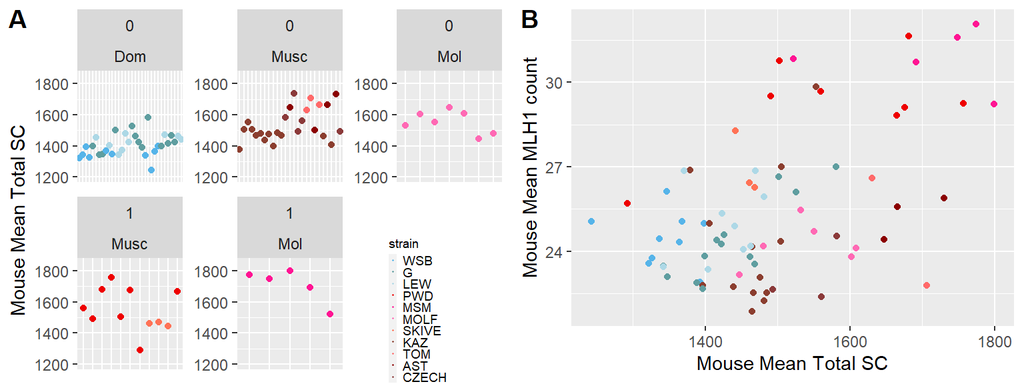

Confirming the basic predictions, there is a positive correlation between mouse mean MLH1 foci per cell and total SC (Spearmans’ r = 0.48; p = 2.2410^{-10}). Nevertheless, mean total SC only partially differentiates high-recombination and low-recombination strains (Figure 5). While high-recombination strains have significantly greater mouse mean total SC area in the total dataset (t-test; p = 0.01), separate tests by strain show that only within *molossinus* are high- and low-recombination strains significantly different (t-test; molossinus: p = 0.03; musculus: p = 0.87).

Additionally, the mouse means for the reduced (short and long) bivalent datasets are not significantly different between high-recombination and low-recombination strains (t-test; short: p = 0.88; long: p = 0.19).

In a general linear model with total SC as the dependent variable, two subspecies effects are significant (*musculus* p = 1.2410^{-6}, *molossinus*, p = 10^{-6}). In general linear models with reduced bivalent means as dependent variables, several subspecies and strain effects reach significance (p < 0.05) but they are not consistent across models, indicating to some extent the chromatin compaction evolution is decoupled from evolution in mean MLH1 foci per cell. **Bret’s comment; How can you differentiate between this biological conclusion and uncertainty due to the size of the datasets and statistical approaches?**

## Single Crossover position is decoupled from genome wide recombination rate evolution

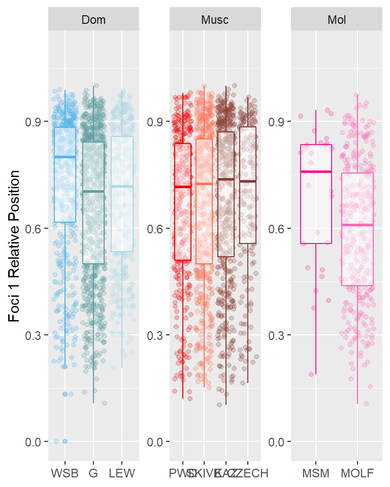

Male distributions of single crossover normalized positions.

## Evolution of interference is associated with genome wide recombination rate evolution

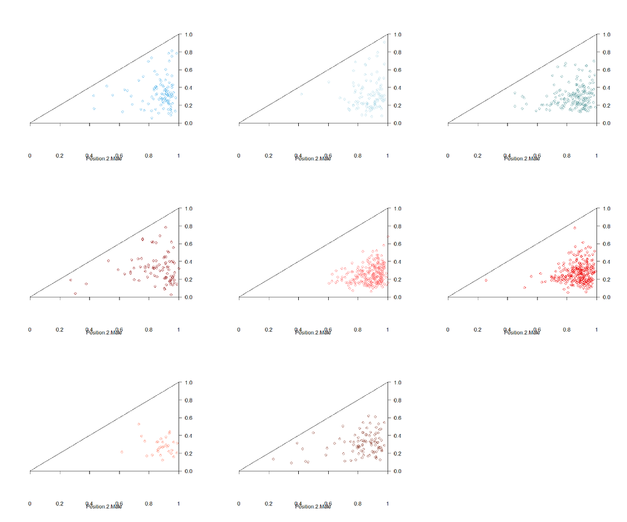

male IFD distributions highlighting differences across recombining groups

Mouse averages for both IFD<sup>raw</sup> and IFD<sup>norm</sup> are significantly longer in high-recombination strains (t-test; IFD<sup>norm</sup>: p = 3.3710^{-4}; IFD<sup>raw</sup>: p = 2.3910^{-4}).

That IFD<sup>raw</sup> and IFD<sup>norm</sup> show similar patterns eliminates variation in SC lengths and bivalent sizes as primary explanations. We determined that the main difference in IFD<sup>norm</sup> distributions between high-recombination and low-recombination strains is an enrichment of IFD<sup>norm</sup> values under 30% in low-recombination strains. The frequency of IFD<sup>norm</sup> values that fall below 30% ranges from 8.2% (*domesticus<sup>G</sup>*) to 16% (*musculus<sup>KAZ</sup>*) in low-recombination strains, whereas high-recombination strains all show such frequencies below 5% (0%, 1.3%, and 3.3% for *musculus<sup>SKIVE</sup>*, *molossinus<sup>MSM</sup>*, and *musculus<sup>PWD</sup>*, respectively).

Differnces in IFD can also be noted from the triangle IFD plots (Figure 6). The three high-recombining strains show more clustering of IFD observations near the area of the plot which indicates longer IFDs. The remaining strains have more observations short IFD observations near the diagonal.

In summary, the level of interference is a significant predictor of evolution in the genome-wide recombination rate, but SC length and crossover position on 1CO bivalents are not. However, the pattern is in the opposite direction to our prediction: high-recombination strains have stronger interference.

# Discussion

An additional possibility is that the different rates in recombination rate variation across subspecies is related to history of hybridization across the populations sampled in this panel of inbred strains. Theoretical work as connected recombination that rate of purging deleterious introgressed DNA in populations after hybridization (Caballero et al 2019, Schumer 2018). The three high-recombining strains identified in this study have connections to hybridization. Both *Musculus<sup>PWD</sup>* and *musculus<sup>SKIVE</sup>* strains were established from samples from the European house mouse hybrid zone. Notably *musculus<sup>SKIVE</sup>* comes from a younger section of the hybrid zone with a nuclear genome from *M. m. musculus* and a mitochondria genome from *M. m. domesticus* (Gyllensten and Wilson 1987). The subspecies *M. m. molossinus* is a natural hybrid of *M. m. musculus* and *M. m. cataneus* (Geraldes et al 2008, (Geraldes et al. 2011)). Models for the aggregate recombination metrics, suggest that the location of recombination events and the total rate influence the dynamics of purging of deleterious introgress DNA (Veller et al 2019), motivating increased study of recombination rates and natural populations.

## Evolution of reversed heterochiasmy direction

In our results and more generally in the literature, female biased heterochiasmy is the most common pattern, however male biased heterochiasmy is not especially rare (Brandvain and Coop 2012). Our results extend previous reports of male biased heterochiasmy (Dumont and Payseur 2011) to new subspecies of house mouse (*molossinus*) and emphasize the short evolutionary period. Whether these instances of evolution of genome-wide recombination rates are due to independent events or segregating genetic variation within house mouse subspecies requires further study. Regardless, the faster male evolution in genome-wide recombination rates suggests that even for species in female biased heterochiasmy species, selecting for higher male specific genome wide recombination rates may be the most effective way to increase the sex-averaged recombination rate for a genetic background. This insight could be important for animal breeding programs (Battagin et al. 2016).

Under the spindle based model, faster male evolution of the genome wide recombination rate, is primarily driven by a more efficient spindle assembly checkpoint (SAC) acting on chromosome structures at metaphase I alignment. The SAC prevents aneuploidy by ensuring all bivalents are correctly attached to the microtubule spindle (bi-orientated) before starting the metaphase-to-anaphase transition (Lane and Kauppi 2019, @subramanian2014, @dumontDesai2012).

A stable chromosome structure requires, i) kinetochores attached to opposite poles of the cells and ii) at least one crossover to create tension across a proportion of sister cohesion (Lane and Kauppi 2019). Genetic variants will be selected in a manner to optimize the process of bi-orientation and prevent SAC from delaying cell cycle or triggering apoptosis. Multiple lines of evidence indicate that the effectiveness of SAC in spermatogenesis is greater compared to oogenesis (Lane and Kauppi 2019, @subramanian2014), which are connected to conserved features of gametogenesis; centrosome spindle (So et al. 2019, @dumontDesai2012) and cell volume (Kyogoku and Kitajima 2017). The more stringent SAC in spermatogenesis will be more effective at removing genetic variants which interfere with bi-orientation compared to females. This dynamic can give rise to sex-specific genetic variants which in turn can result in context of meiosis between males and females as the primary source of distinct evolutionary trajectories in genome wide recombination rates.

## Conservation in sexual dimorphism in between cell variation in crossover number

In the spindle based selection model, the less efficient SAC in oocytes leads to relaxed selection on the metaphase I chromosome structure. This will result in increased variance in chromosome structure and crossover number per cell, not just across strains, but across cells within individuals. Oocytes at metaphase I, have an acentriolar spindle comprised of diffuse network of microtubules with multiple microtubule organizing centers (Schuh and Ellenberg 2007). Centrosomes act as the two MTOCs for the spindle during spermatogenesis and mitosis. The delivery of centrioles (most mammals) or centriole material (rodents and rabbits) to the egg is thought to be a barrier to evolution of parthenogenesis (Manandhar, Schatten, and Sutovsky 2005).This is another way the spindle based selection model is linked to conserved sex differences in gametogenesis (Ross and Normark 2015).

Regardless of whether these hypotheses are true, our observations of levels of between cell variation fail to support a basic prediction of that a higher mean will be associated with a higher variance. Across all strains, including the high-recombining strains, *muscuslus<sup>PWD</sup>*, *muscuslus<sup>SKIVE</sup>* and *molossinus<sup>MSM</sup>*, females consistently have higher between cell variance for crossover count. These results add to previous findings in mice and humans that oogenesis has increased variance for crossovers (Lynn et al. 2002), (Gruhn et al. 2013) and precursors to crossovers (Lenzi et al. 2005), compared to spermatocytes. This feature of heterochiasmy supports evolutionary theories predicting distinct reproductive strategies between females (diversifying offspring) and males (maintain successful haplotypes) (Trivers and others 2002).

## Conservation in sex-specific recombination landscape

Our results extend the plethora or previous data reports for broad scale sex difference in the recombination landscape (Sardell and Kirkpatrick 2020) are data comprised mostly of species with large evolutionary distances. In contrast our results demonstrate that this pattern is maintained across much shorter evolutionary distances and even with rapid evolution in the genome-wide recombination rate. We argue that this conservation of the male chromosome end bias is one of the most conserved features of heterochiasmy and could be connected to fundamental aspects of gametogenesis.

As reviewed in (Sardell and Kirkpatrick 2020), sexual dimorphism in the broad scale recombination landscape is a conserved trait. The two locus modifier and SACE models predict sexual dimorphism in the broad scale recombination landscape, for diminishing the effect of drive systems and maintaining larger chromosome blocks under linkage in males respectively. The COM model, predicts the sex differences in the recombination landscape via interference is due to a combination of the length of the axis and differing strengths of chromosome movements during the pairing process (Hultén 2011).

Under the spindle based model we hypothesize that the sexual dimorphism in the recombination landscapes hinges on sex differences on the requirements for chromosome cohesion in late meiosis I. The irreversible process of the metaphase to anaphase transition is initiated by the protyltic decay of the sister cohesion connecting homologs (Lane and Kauppi (2019), Subramanian and Hochwagen (2014), Dumont and Desai (2012)). The number and placement of crossovers alter the distribution of sister cohesion and the resulting chromosome structure when bivalents are aligned and bi-oriented on the metaphase plate (Veen and Hawley 2003, @altendorfer2020). Differences in timing of cell cycle between oogenesis and spermatogenesis imposes the the different selective pressures on how sister cohesion affects chromosome structure. Faster spermatogenesis may select for synchronization of the separation homologs (cite). While in oogenesis, the slower cell cycle and multiple arrest stages may require chromosome structures with greater stability on the MI spindle, especially for those with dicyate arrest (Lee 2019).

The increased genetic diversity and recombination rates at chromosome ends Haenel et al. (2018) suggests that this is driven by the male-specific recombination landscape (Sardell and Kirkpatrick 2020), which provides some interesting evolutionary predictions.

## Conservation of sex differences in chromatin structure

Our results from *musculus<sup>MSM</sup>* and *musculus<sup>PWD</sup>* demonstrate that chromatin compaction are uncoupled from the direction of heterochiasmy in house mice. These results slightly depart from predictions which nominate chromatin compaction as the primary driver of recombination rate variation (Petkov et al. 2007). Chromatin compaction could explain variation in heterochiasmy, which is driven by the distinct meiotic contexts across sexes but is a weak predictor for recombination rate variation within the sexes. Our results indicate the sexual dimorphism in chromatin compaction is conserved in house mouse (e.g. females have longer SC than males) and that the rapid male-specific evolution in crossover number per cell proceeded through another aspect of crossover regulation (see below).

Only the COM model predicts sexual dimorphism in chromatin structure and attributes the source to greater cell volume in oocytes. This prediction model might fit broader pattern such as in *Arabidopsis thalania* (Mercier, Sera) where pollen is the larger cell and has longer axis length (Cahoon and Libuda 2019).

As outlined in Haenel et al. (2018), sexual dimorphism in chromatin organization translates to interference strength measured in base pairs. From empirical data in mice (Petkov et al. 2007), (Lynn et al. 2002) and humans (Gruhn et al. 2013), there seem to be to general configurations for chromatin structure: longer axis and shorter loops in females; shorter axis and longer loops in males. The signal for interference is thought to be mediated though the SC, which is built on top of the chromosome axis (Zickler and Kleckner 2015) regardless of the loop size. Supporting this is the observation that interference strength measured in micrometers of is conserved between sexes (Petkov et al. 2007). As a consequence, since more base pairs are sequestered into the radial loops per unit of the linear central axis, chromatin organization with longer DNA loops (and shorter axis), as seen in males, will have a signal of stronger interference when measured in base pairs compared to ’the typical female chromatin configuration. Stronger interference in males, has been noted across many sex-specific linkage maps (cite) strengthening the hypothesis that sexual dimorphism in the chromatin organization is widespread, however this has only been confirmed by cytological data in mice and humans. (Also large difficulties in observing sperm cells through meiosis).

## Evolution of interference strength in males

An expected consequence of our observed elevated genome-wide recombination rate is lower LD across the genome, which may increase the efficiency of selection and impact the dynamics of introgression (Schumer). Given that the higher genome-wide recombination rates are paired with stronger interference these predicted pattern may have heterogeneous signal along chromosomes.

Examples of evolution of interference strength are rare and may be complicated by changes in the underlying karyotype structure (Segura et al 2014). The general pattern of empirical measures of interference strength is that it has a negative correlation to the genome wide recombination rate (Otto and Payseur 2019). This fits the logic of the chromosome axis acting as the ‘real estate’ for DSBs and aligns with known molecular mechanisms (cite). Two examples of the opposite direction, a positive correlation of interference strength and genome-wide recombination rate, involve descriptions of observations at the single bivalent level; the between lab-raised and wild mice of *Peromyscus leucopus* from (Peterson, Miller, and Payseur 2019) or large effects on genome wide recombination rates across a short evolutionary differences; the within-sex comparison of two breeds of cattle with different genome wide recombination rates (Ma et al. 2015).

The COM model predicts that interference and the recombination landscape arises from known oscillatory movements during prophase (Rubin, Macaisne, and Huynh 2020), however it lacks a mechanism for a evolutionary based predictions. While the SACE modifier model does not explicitly model evolution of interference strength we note that a logical outcome of the main prediction of maintaining larger chromosome blocks in males, would be a recombination landscape with stronger interference strength.

We have focused on the model involving direct selection on the recombination pathway, which has an impact on the fitness of an individual, but we acknowledge connections to other models involving indirect selection on recombination rates which involve the fitness outcomes of offspring. A model from Goldstein, Bergman, and Feldman (1993), reviewed in (Otto and Payseur 2019) and Veller, Kleckner, and Nowak (2019), predict that interference strength evolves whenever increased recombination rates evolve. The simulations under this model indicate that the space across multiple loci or between multiple crossovers increases in a positive manner with the genome wide recombination rate. A distinguishing feature of this model from other modifier models is that the number of crossovers per chromosome is kept constant. Empirically, the range of crossovers per chromosome is quite limited, 1-3, for the majority of chromosomes across most taxa (Otto and Payseur 2019, @stapley_variation_2017). Constraining the number of crossovers per chromosome in models may fit empirical data better than those where recombination rate across an abstracted genetic space is unconstrained.

## Future steps

There are still many un-known aspects regarding heterochiasmy (Lenormand et al. (2016)) — that would benefit from the cross-pollination of physiology based models and more abstract model such as population genetic models with testable hypotheses Dapper and Payseur (2017). A goal of such merging of models could be to connect empirical findings across scales. We make two suggestions for future steps in studying recombination variation. First consider the when comparing sex specific meiotic traits consider that evolutionary distinct trajectories due to the fundamental differences in gametogenesis. Second certain systems can be leveraged to overcome limitations inherent in some approached. For example, identifying chromosomes across cells in cytological data requires chromosome specific probes, (e.g. FISH) but chromosome specific data can be collected from organisms with diverse karyotypes (birds, peromyscus, humans) or backgrounds with Robertsonian trans-locations.

# References

Altendorfer, Elisabeth, Laura I Láscarez-Lagunas, Saravanapriah Nadarajan, Iain Mathieson, and Monica P Colaiácovo. 2020. “Crossover Position Drives Chromosome Remodeling for Accurate Meiotic Chromosome Segregation.” *Current Biology*.

Anderson, Lorinda K, Aaron Reeves, Lisa M Webb, and Terry Ashley. 1999. “Distribution of Crossing over on Mouse Synaptonemal Complexes Using Immunofluorescent Localization of Mlh1 Protein.” *Genetics* 151 (4): 1569–79.

Battagin, Mara, Gregor Gorjanc, Anne-Michelle Faux, Susan E Johnston, and John M Hickey. 2016. “Effect of Manipulating Recombination Rates on Response to Selection in Livestock Breeding Programs.” *Genetics Selection Evolution* 48 (1): 44.

Brandvain, Yaniv, and Graham Coop. 2012. “Scrambling Eggs: Meiotic Drive and the Evolution of Female Recombination Rates.” *Genetics* 190 (2): 709–23.

Cahoon, Cori K, and Diana E Libuda. 2019. “Leagues of Their Own: Sexually Dimorphic Features of Meiotic Prophase I.” *Chromosoma*, 1–16.

Cole, Francesca, Liisa Kauppi, Julian Lange, Ignasi Roig, Raymond Wang, Scott Keeney, and Maria Jasin. 2012. “Homeostatic Control of Recombination Is Implemented Progressively in Mouse Meiosis.” *Nature Cell Biology* 14 (4): 424–30.

Dapper, Amy L, and Bret A Payseur. 2017. “Connecting Theory and Data to Understand Recombination Rate Evolution.” *Philosophical Transactions of the Royal Society B: Biological Sciences* 372 (1736): 20160469.

Dumont, Beth L, and Bret A Payseur. 2011. “Genetic Analysis of Genome-Scale Recombination Rate Evolution in House Mice.” *PLoS Genetics* 7 (6).

Dumont, Julien, and Arshad Desai. 2012. “Acentrosomal Spindle Assembly and Chromosome Segregation During Oocyte Meiosis.” *Trends in Cell Biology* 22 (5): 241–49.

Geraldes, Armando, Patrick Basset, Kimberley L Smith, and Michael W Nachman. 2011. “Higher Differentiation Among Subspecies of the House Mouse (Mus Musculus) in Genomic Regions with Low Recombination.” *Molecular Ecology* 20 (22): 4722–36.

Goldstein, David B, Aviv Bergman, and Marcus W Feldman. 1993. “The Evolution of Interference: Reduction of Recombination Among Three Loci.” *Theoretical Population Biology* 44 (2): 246–59.

Gruhn, Jennifer R, Carmen Rubio, Karl W Broman, Patricia A Hunt, and Terry Hassold. 2013. “Cytological Studies of Human Meiosis: Sex-Specific Differences in Recombination Originate at, or Prior to, Establishment of Double-Strand Breaks.” *PloS One* 8 (12).

Gyllensten, Ulf, and Allan C Wilson. 1987. “Interspecific Mitochondrial Dna Transfer and the Colonization of Scandinavia by Mice.” *Genetics Research* 49 (1): 25–29.

Haenel, Quiterie, Telma G Laurentino, Marius Roesti, and Daniel Berner. 2018. “Meta-Analysis of Chromosome-Scale Crossover Rate Variation in Eukaryotes and Its Significance to Evolutionary Genomics.” *Molecular Ecology* 27 (11): 2477–97.

Hultén, Maj A. 2011. “On the Origin of Crossover Interference: A Chromosome Oscillatory Movement (Com) Model.” *Molecular Cytogenetics* 4 (1): 10.

Koehler, Kara E, Jonathan P Cherry, Audrey Lynn, Patricia A Hunt, and Terry J Hassold. 2002. “Genetic Control of Mammalian Meiotic Recombination. I. Variation in Exchange Frequencies Among Males from Inbred Mouse Strains.” *Genetics* 162 (1): 297–306.

Kyogoku, Hirohisa, and Tomoya S Kitajima. 2017. “Large Cytoplasm Is Linked to the Error-Prone Nature of Oocytes.” *Developmental Cell* 41 (3): 287–98.

Lane, Simon, and Liisa Kauppi. 2019. “Meiotic Spindle Assembly Checkpoint and Aneuploidy in Males Versus Females.” *Cellular and Molecular Life Sciences* 76 (6): 1135–50.

Lee, Jibak. 2019. “Is Age-Related Increase of Chromosome Segregation Errors in Mammalian Oocytes Caused by Cohesin Deterioration?” *Reproductive Medicine and Biology*.

Lenormand, Thomas, Jan Engelstädter, Susan E Johnston, Erik Wijnker, and Christoph R Haag. 2016. “Evolutionary Mysteries in Meiosis.” *Philosophical Transactions of the Royal Society B: Biological Sciences* 371 (1706): 20160001.

Lenzi, Michelle L, Jenetta Smith, Timothy Snowden, Mimi Kim, Richard Fishel, Bradford K Poulos, and Paula E Cohen. 2005. “Extreme Heterogeneity in the Molecular Events Leading to the Establishment of Chiasmata During Meiosis I in Human Oocytes.” *The American Journal of Human Genetics* 76 (1): 112–27.

Lynn, Audrey, Kara E Koehler, LuAnn Judis, Ernest R Chan, Jonathan P Cherry, Stuart Schwartz, Allen Seftel, Patricia A Hunt, and Terry J Hassold. 2002. “Covariation of Synaptonemal Complex Length and Mammalian Meiotic Exchange Rates.” *Science* 296 (5576): 2222–5.

Ma, Li, Jeffrey R O’Connell, Paul M VanRaden, Botong Shen, Abinash Padhi, Chuanyu Sun, Derek M Bickhart, et al. 2015. “Cattle Sex-Specific Recombination and Genetic Control from a Large Pedigree Analysis.” *PLoS Genetics* 11 (11).

Manandhar, Gaurishankar, Heide Schatten, and Peter Sutovsky. 2005. “Centrosome Reduction During Gametogenesis and Its Significance.” *Biology of Reproduction* 72 (1): 2–13.

Mercier, Raphaël, Christine Mézard, Eric Jenczewski, Nicolas Macaisne, and Mathilde Grelon. 2015. “The Molecular Biology of Meiosis in Plants.” *Annual Review of Plant Biology* 66: 297–327.

Otto, Sarah P, and Bret A Payseur. 2019. “Crossover Interference: Shedding Light on the Evolution of Recombination.” *Annual Review of Genetics* 53: 19–44.

Peters, Antoine HFM, Annemieke W. Plug, Martine J. van Vugt, and Peter De Boer. 1997. “SHORT COMMUNICATIONS A Drying-down Technique for the Spreading of Mammalian Meiocytes from the Male and Female Germline.” *Chromosome Research* 5 (1): 66–68.

Peterson, April L, Nathan D Miller, and Bret A Payseur. 2019. “Conservation of the Genome-Wide Recombination Rate in White-Footed Mice.” *Heredity* 123 (4): 442–57.

Petkov, Petko M, Karl W Broman, Jin P Szatkiewicz, and Kenneth Paigen. 2007. “Crossover Interference Underlies Sex Differences in Recombination Rates.” *Trends in Genetics* 23 (11): 539–42.

Ross, L, and BB Normark. 2015. “Evolutionary Problems in Centrosome and Centriole Biology.” *Journal of Evolutionary Biology* 28 (5): 995–1004.

Rubin, Thomas, Nicolas Macaisne, and Jean-René Huynh. 2020. “Mixing and Matching Chromosomes During Female Meiosis.” *Cells* 9 (3): 696.

Sardell, Jason M., and Mark Kirkpatrick. 2020. “Sex Differences in the Recombination Landscape.” *The American Naturalist* 195 (2): 361–79. https://doi.org/10.1086/704943.

Schindelin, Johannes, Ignacio Arganda-Carreras, Erwin Frise, Verena Kaynig, Mark Longair, Tobias Pietzsch, Stephan Preibisch, Curtis Rueden, Stephan Saalfeld, and Benjamin Schmid. 2012. “Fiji: An Open-Source Platform for Biological-Image Analysis.” *Nature Methods* 9 (7): 676.

Schuh, Melina, and Jan Ellenberg. 2007. “Self-Organization of Mtocs Replaces Centrosome Function During Acentrosomal Spindle Assembly in Live Mouse Oocytes.” *Cell* 130 (3): 484–98.

So, Chun, K Bianka Seres, Anna M Steyer, Eike Mönnich, Dean Clift, Anastasija Pejkovska, Wiebke Möbius, and Melina Schuh. 2019. “A Liquid-Like Spindle Domain Promotes Acentrosomal Spindle Assembly in Mammalian Oocytes.” *Science* 364 (6447): eaat9557.

Stapley, Jessica, Philine G. D. Feulner, Susan E. Johnston, Anna W. Santure, and Carole M. Smadja. 2017. “Variation in Recombination Frequency and Distribution Across Eukaryotes: Patterns and Processes.” *Philosophical Transactions of the Royal Society B: Biological Sciences* 372 (1736): 20160455. https://doi.org/10.1098/rstb.2016.0455.

Subramanian, Vijayalakshmi V, and Andreas Hochwagen. 2014. “The Meiotic Checkpoint Network: Step-by-Step Through Meiotic Prophase.” *Cold Spring Harbor Perspectives in Biology* 6 (10): a016675.

Team, RStudio. 2015. “RStudio: Integrated Development Environment for R.” Boston, MA. http://www.rstudio.com.

Trivers, Robert, and others. 2002. *Natural Selection and Social Theory: Selected Papers of Robert Trivers*. Oxford University Press, USA.

Veen, J Edward van, and R Scott Hawley. 2003. “Meiosis: When Even Two Is a Crowd.” *Current Biology* 13 (21): R831–R833.

Veller, Carl, Nancy Kleckner, and Martin A Nowak. 2019. “A Rigorous Measure of Genome-Wide Genetic Shuffling That Takes into Account Crossover Positions and Mendel’s Second Law.” *Proceedings of the National Academy of Sciences* 116 (5): 1659–68.

Wang, RJ, BL Dumont, P Jing, and BA Payseur. 2019. “A First Genetic Portrait of Synaptonemal Complex Variation.” *PLoS Genetics* 15 (8): e1008337–e1008337.

Zickler, Denise, and Nancy Kleckner. 1999. “Meiotic Chromosomes: Integrating Structure and Function.” *Annual Review of Genetics* 33 (1): 603–754.

———. 2015. “Recombination, Pairing, and Synapsis of Homologs During Meiosis.” *Cold Spring Harbor Perspectives in Biology* 7 (6): a016626.